# Lab 5: T-tests

Justin Baumann

2/15/2022

# **LEARNING OBJECTIVES**

IN THIS TUTORIAL YOU WILL LEARN:  
1.) The theory behind a T-test and how to perform one  
2.) Practice data preparation skills  
3.) How to pair graphs and stats to test hypotheses

# Additional Tutorials and Resources for basic statistics in R

t-tests

```r
library(tidyverse)  #For data manipulation and graphing
```

[output not shown]

```r
library(ggridges)  #For making nice looking density plots/histograms
library(patchwork)  #to panel our graphs
library(ggsci)  #for easy color palletes!
library(car)  #contains some statistical tests we need to assess assumptions
```

# **2.) A note on statistics and experimental design**

Statistics is a complex field with a long history. We could spend an entire course or even an entire career focusing on the intricate details of statistical decisions and ideas. We’ve already spent some time on this! I want you to have the statistical grounding necessary to plan your experiments and analyze your data. For biologists, statistics are a tool we can leverage to perform the best possible experiments and test our hypotheses. The T-test is the start of our stats journey. It’s a simple test and one that you may not use often, but the theory behind it sets the stage for what is to come!

# **3.) The T-test**

## **T-test theory**

The t-test (or students’ t-test) is a basic statistical test used to assess whether or not the means of two groups are different from one another. In this test, the null hypothesis is that the two means are equal (or that there is no difference between the two means).

**A t-test should only be used if the following assumptions are met:**  
**1.)** the two distributions whose means we are comparing must be **normally distributed**  
**2.)** The variances of the two groups must be **equal**

**Generate example data**

```r
iris2<-iris %>%
  filter(Species != 'setosa') %>%
  droplevels() #removes the empty levels so when we check levels below we only get the ones that are still in the data!

#check levels to make sure we only have 2 species!
head(iris2)
```

```
##   Sepal.Length Sepal.Width Petal.Length Petal.Width    Species
## 1          7.0         3.2          4.7         1.4 versicolor
## 2          6.4         3.2          4.5         1.5 versicolor
## 3          6.9         3.1          4.9         1.5 versicolor
## 4          5.5         2.3          4.0         1.3 versicolor
## 5          6.5         2.8          4.6         1.5 versicolor
## 6          5.7         2.8          4.5         1.3 versicolor
```

```r
levels(iris2$Species)
```

```
## [1] "versicolor" "virginica"
```

We will use these data for our examples today. T-test requires *only* 2 groups/populations. We will assess the alternative hypothesis that one of our numerical variables (sepal length, sepal width, petal length, or petal width) differs by species.

But first, we must **test our assumptions**

## **Assumption 1.) Assessing normality**

*Method 1: the Shapiro-Wilk Test* If p < 0.05 then the distribution is significantly different from normal.

Step 1: we need to create separate data frames for each species to assess normality of each variable by species!

```r
versi<-iris2 %>%
  filter(Species=='versicolor') %>%
  droplevels()

virg<-iris2 %>%
  filter(Species=='virginica') %>%
  droplevels()
```

Step 2: We can run our shapiro-wilk tests on each variable if we’d like

```r
shapiro.test(versi$Petal.Length) #this is normally distributed
```

```
##
##  Shapiro-Wilk normality test
##
## data:  versi$Petal.Length
## W = 0.966, p-value = 0.1585
```

```r
shapiro.test(versi$Petal.Width) # this is not
```

```
##
##  Shapiro-Wilk normality test
##
## data:  versi$Petal.Width
## W = 0.94763, p-value = 0.02728
```

```r
shapiro.test(versi$Sepal.Length) #normal
```

```
##
##  Shapiro-Wilk normality test
##
## data:  versi$Sepal.Length
## W = 0.97784, p-value = 0.4647
```

```r
shapiro.test(versi$Sepal.Width) #normal
```

```
##
##  Shapiro-Wilk normality test
##
## data:  versi$Sepal.Width
## W = 0.97413, p-value = 0.338
```

```r
shapiro.test(virg$Petal.Length) #normal
```

```
##
##  Shapiro-Wilk normality test
##
## data:  virg$Petal.Length
## W = 0.96219, p-value = 0.1098
```

```r
shapiro.test(virg$Petal.Width) #normal
```

```
##
##  Shapiro-Wilk normality test
##
## data:  virg$Petal.Width
## W = 0.95977, p-value = 0.08695
```

```r
shapiro.test(virg$Sepal.Length) #normal
```

```
##
##  Shapiro-Wilk normality test
##
## data:  virg$Sepal.Length
## W = 0.97118, p-value = 0.2583
```

```r
shapiro.test(virg$Sepal.Width) #normal
```

```
##
##  Shapiro-Wilk normality test
##
## data:  virg$Sepal.Width
## W = 0.96739, p-value = 0.1809
```

*Method 2: Visualization*

Explore the following visualizations. Do you see clear evidence of normality?

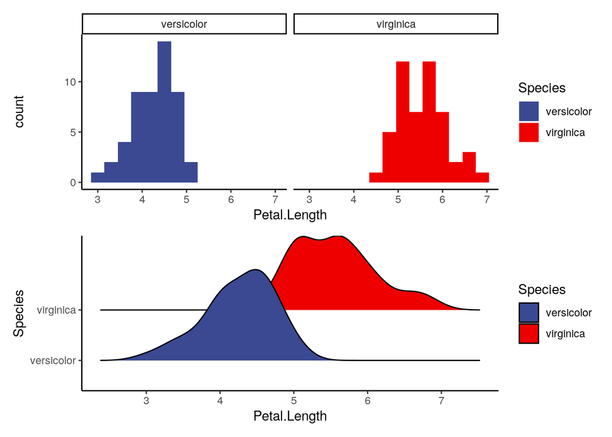

```r
a1<-ggplot(data=iris2, aes(Petal.Length, fill=Species))+
  geom_histogram(binwidth = 0.3)+
  facet_wrap(~Species)+
  theme_classic()+
  scale_fill_aaas()

a2<-ggplot(data=iris2, aes(x=Petal.Length, y=Species, fill=Species))+
  geom_density_ridges()+ #makes a smooth density curve instead of a histogram!
  theme_classic()+
  scale_fill_aaas()

a1/a2 #compare the visualizations (they are of the same data)- do we see normality here?
```

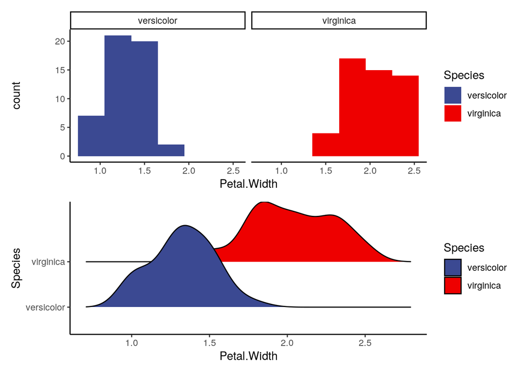

```r
b1<-ggplot(data=iris2, aes(Petal.Width, fill=Species))+
  geom_histogram(binwidth = 0.3)+
  facet_wrap(~Species)+
  theme_classic()+
  scale_fill_aaas()

b2<-ggplot(data=iris2, aes(x=Petal.Width, y=Species, fill=Species))+
  geom_density_ridges()+ #makes a smooth density curve instead of a histogram!
  theme_classic()+
  scale_fill_aaas()

b1/b2 #compare the visualizations (they are of the same data)- do we see normality here?
```

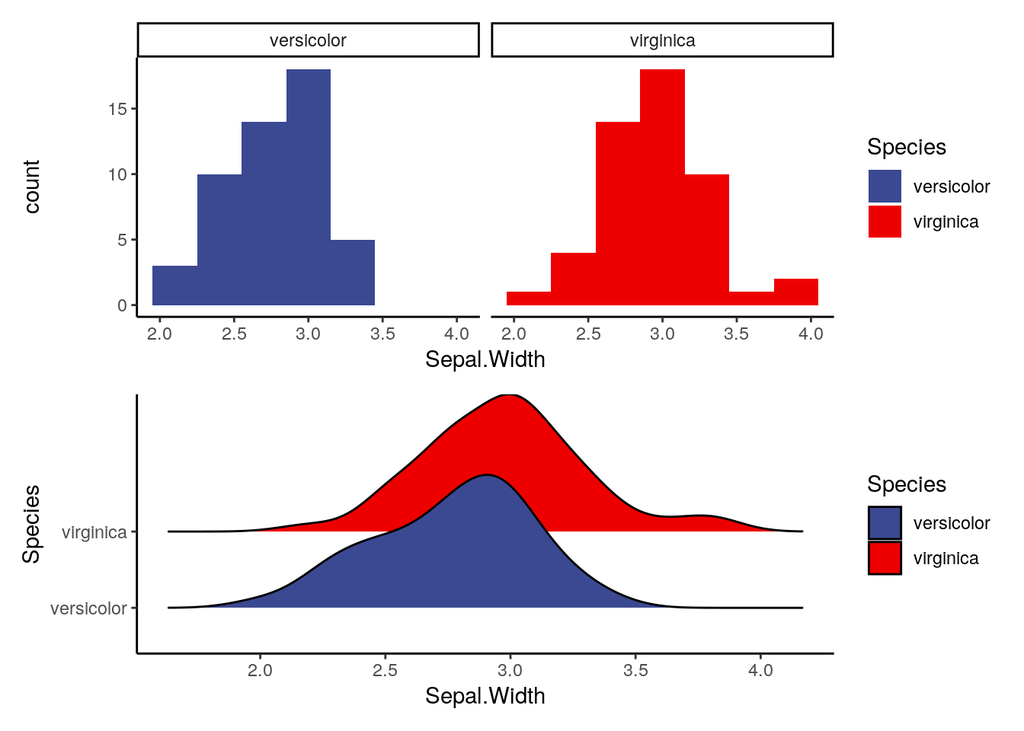

```r
c1<-ggplot(data=iris2, aes(Sepal.Width, fill=Species))+
  geom_histogram(binwidth = 0.3)+
  facet_wrap(~Species)+
  theme_classic()+
  scale_fill_aaas()

c2<-ggplot(data=iris2, aes(x=Sepal.Width, y=Species, fill=Species))+
  geom_density_ridges()+ #makes a smooth density curve instead of a histogram!
  theme_classic()+
  scale_fill_aaas()

c1/c2 #compare the visualizations (they are of the same data)- do we see normality here?
```

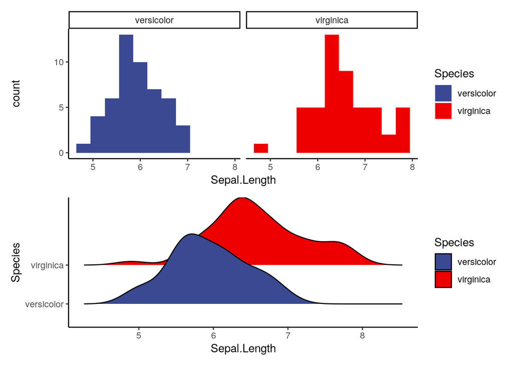

```r
d1<-ggplot(data=iris2, aes(Sepal.Length, fill=Species))+
  geom_histogram(binwidth = 0.3)+
  facet_wrap(~Species)+
  theme_classic()+
  scale_fill_aaas()

d2<-ggplot(data=iris2, aes(x=Sepal.Length, y=Species, fill=Species))+
  geom_density_ridges()+ #makes a smooth density curve instead of a histogram!
  theme_classic()+
  scale_fill_aaas()

d1/d2 #compare the visualizations (they are of the same data)- do we see normality here?
```

## **Assumption 2.) Assessing equal variance**

AKA homogeneity of variance

**Methods 1: F-test** We will use the **F-Test** to compare the variance of two populations. This can only be used with *2* populations and is thus only useful when we run a t-test.

H0 for an F-test is: The variances of the two groups are equal.  
Ha: The variances are different  
p<0.05 allows us to reject the null (H0) and suggests that the variances are different  
**note:** The F-test assumes our data are already normal! You should not run it on non-normal data

```r
#we use var.test to run an F-test
f1<- var.test(Petal.Length ~ Species, data=iris2)
f1 # p>0.05, so we fail to reject H0 (the variances are likely equal)
```

```
##
##  F test to compare two variances
##
## data:  Petal.Length by Species
## F = 0.72497, num df = 49, denom df = 49, p-value = 0.2637
## alternative hypothesis: true ratio of variances is not equal to 1
## 95 percent confidence interval:
##  0.411402 1.277530
## sample estimates:
## ratio of variances
##          0.7249678
```

```r
f2<- var.test(Petal.Width ~ Species, data=iris2)
f2 # p<0.05, so we reject H0 (variances are likely different)
```

```
##
##  F test to compare two variances
##
## data:  Petal.Width by Species
## F = 0.51842, num df = 49, denom df = 49, p-value = 0.02335
## alternative hypothesis: true ratio of variances is not equal to 1
## 95 percent confidence interval:
##  0.2941935 0.9135614
## sample estimates:
## ratio of variances
##          0.5184243
```

```r
f3<- var.test(Sepal.Length ~ Species, data=iris2)
f3 # p>0.05, so we fail to reject H0 (the variances are likely equal)
```

```
##
##  F test to compare two variances
##
## data:  Sepal.Length by Species
## F = 0.65893, num df = 49, denom df = 49, p-value = 0.1478
## alternative hypothesis: true ratio of variances is not equal to 1
## 95 percent confidence interval:
##  0.3739257 1.1611546
## sample estimates:
## ratio of variances
##          0.6589276
```

```r
f4<- var.test(Sepal.Width ~ Species, data=iris2)
f4 # p>0.05, so we fail to reject H0 (the variances are likely equal)
```

```
##
##  F test to compare two variances
##
## data:  Sepal.Width by Species
## F = 0.94678, num df = 49, denom df = 49, p-value = 0.849
## alternative hypothesis: true ratio of variances is not equal to 1
## 95 percent confidence interval:
##  0.5372773 1.6684117
## sample estimates:
## ratio of variances
##          0.9467839
```

**Method 2: Levene Test**  
A more flexible test of homogeneity of variance is the Levene Test. It can be used to compare the variance of many populations (not just 2) and is more flexible than the F-test, so it can be used even if the normality assumption is violated.  
**this is the most commonly used test for homogeneity of variance**  
**leveneTest() is in the car package in R!**

N0: Variances of all populationos are equal  
p<0.05 allows us to reject H0

```r
l1<- leveneTest(Petal.Length ~ Species, data=iris2)
l1 # p>0.05, so we fail to reject H0 (the variances are likely equal)
```

```
## Levene's Test for Homogeneity of Variance (center = median)
##       Df F value Pr(>F)
## group  1  1.0674 0.3041
##       98
```

```r
l2<- leveneTest(Petal.Width ~ Species, data=iris2)
l2 # p<0.05, so we reject H0 (variances are likely different)
```

```
## Levene's Test for Homogeneity of Variance (center = median)
##       Df F value  Pr(>F)
## group  1  6.5455 0.01205 *
##       98
## ---
## Signif. codes:  0 '***' 0.001 '**' 0.01 '*' 0.05 '.' 0.1 ' ' 1
```

```r
l3<- leveneTest(Sepal.Length ~ Species, data=iris2)
l3 # p>0.05, so we fail to reject H0 (the variances are likely equal)
```

```
## Levene's Test for Homogeneity of Variance (center = median)
##       Df F value Pr(>F)
## group  1  1.0245 0.3139
##       98
```

```r
l4<- leveneTest(Sepal.Width ~ Species, data=iris2)
l4 # p>0.05, so we fail to reject H0 (the variances are likely equal)
```

```
## Levene's Test for Homogeneity of Variance (center = median)
##       Df F value Pr(>F)
## group  1  0.0873 0.7683
##       98
```

**Method 3: Visualization**  
Since p-values are more like guidelines, we also want to visualize our data to assess homogeniety of variance. We can do that in several ways. You might already have some ideas about this! In general, it seems smart to display the raw data as points and as boxplots. Let’s start there!

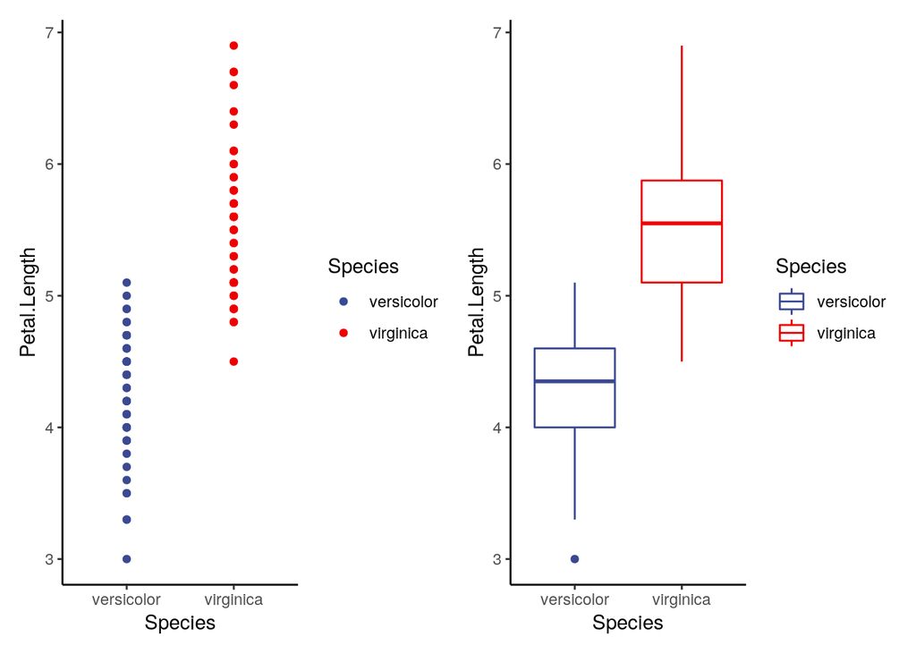

```r
v1.1<-ggplot(data=iris2, aes(x=Species, y=Petal.Length, color=Species))+
  geom_point()+
  theme_classic()+
  scale_color_aaas()

v1.2<-ggplot(data=iris2, aes(x=Species, y=Petal.Length, color=Species))+
  geom_boxplot()+
  theme_classic()+
  scale_color_aaas()

v1.1+v1.2
```

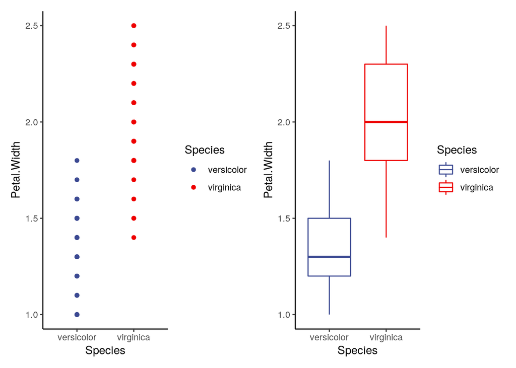

```r
v2.1<-ggplot(data=iris2, aes(x=Species, y=Petal.Width, color=Species))+
  geom_point()+
  theme_classic()+
  scale_color_aaas()

v2.2<-ggplot(data=iris2, aes(x=Species, y=Petal.Width, color=Species))+
  geom_boxplot()+
  theme_classic()+
  scale_color_aaas()

v2.1+v2.2
```

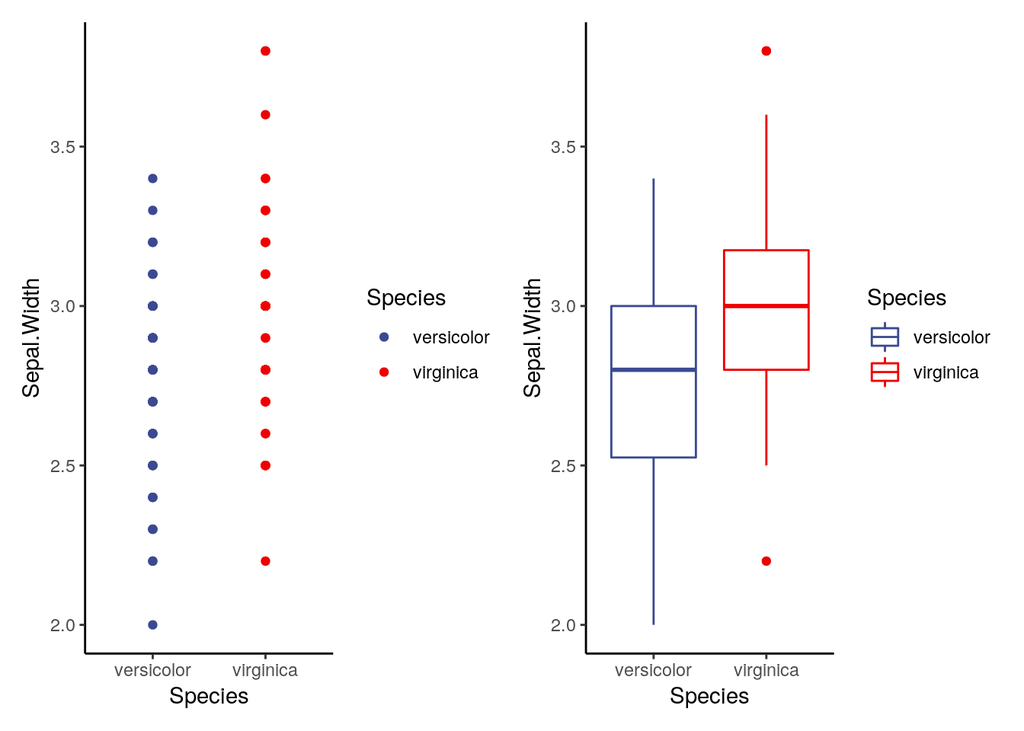

```r
v3.1<-ggplot(data=iris2, aes(x=Species, y=Sepal.Width, color=Species))+
  geom_point()+
  theme_classic()+
  scale_color_aaas()

v3.2<-ggplot(data=iris2, aes(x=Species, y=Sepal.Width, color=Species))+
  geom_boxplot()+
  theme_classic()+
  scale_color_aaas()

v3.1+v3.2
```

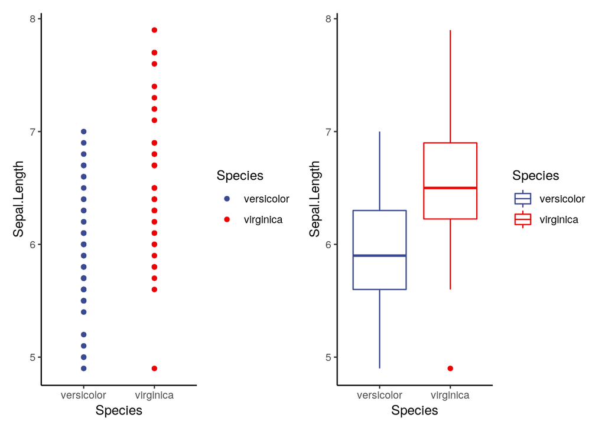

```r
v4.1<-ggplot(data=iris2, aes(x=Species, y=Sepal.Length, color=Species))+
  geom_point()+
  theme_classic()+
  scale_color_aaas()

v4.2<-ggplot(data=iris2, aes(x=Species, y=Sepal.Length, color=Species))+
  geom_boxplot()+
  theme_classic()+
  scale_color_aaas()

v4.1+v4.2
```

## **When can we ignore assumptions?**

We can if our sample sizes are large. If n is small, we should not ignore this assumption. There are alternatives to dealing with normality that we can discuss in the ANOVA section (such as transforming the data)

[For more info on that](https://thestatsgeek.com/2013/09/28/the-t-test-and-robustness-to-non-normality/)

We can also ignore the equal variance requirement if we use the Welch t-test (default in R)

## **A basic T-test in R**

Let’s compare two columns in the mtcars data frame

Do the means of mpg and cyl differ?

```r
t1<-t.test(mtcars$mpg,mtcars$cyl, alternative='two.sided', var.equal=FALSE) #two.sided and var.equal= FALSE are default, so we don't have to list them. BUt, we can also change them (as I will show later)

t1
```

```
##
##  Welch Two Sample t-test
##
## data:  mtcars$mpg and mtcars$cyl
## t = 12.512, df = 36.402, p-value = 9.508e-15
## alternative hypothesis: true difference in means is not equal to 0
## 95 percent confidence interval:
##  11.65034 16.15591
## sample estimates:
## mean of x mean of y
##  20.09062   6.18750
```

**Is the mean of mpg > cyl?**

```r
t2<-t.test(mtcars$mpg,mtcars$cyl, alternative='greater', var.equal=FALSE) #'greater' here technically asks if the diffrence in means is > zero (in which case, the variable listed first would have a mean higher than the variable listed second)

t2
```

```
##
##  Welch Two Sample t-test
##
## data:  mtcars$mpg and mtcars$cyl
## t = 12.512, df = 36.402, p-value = 4.754e-15
## alternative hypothesis: true difference in means is greater than 0
## 95 percent confidence interval:
##  12.02761      Inf
## sample estimates:
## mean of x mean of y
##  20.09062   6.18750
```

```r
t3<-t.test(mtcars$mpg,mtcars$cyl, alternative='less', var.equal=FALSE) #'less' here technically asks if the diffrence in means is < zero (in which case, the variable listed first would have a mean lower than the variable listed second)

t3
```

```
##
##  Welch Two Sample t-test
##
## data:  mtcars$mpg and mtcars$cyl
## t = 12.512, df = 36.402, p-value = 1
## alternative hypothesis: true difference in means is less than 0
## 95 percent confidence interval:
##      -Inf 15.77864
## sample estimates:
## mean of x mean of y
##  20.09062   6.18750
```

As you can see, we can use a t-test to tell us if there is a difference in means between the two groups we are looking at. Which is fine, but not always very useful. Our example here was totally frivolous. We don’t need statistics to tell us that the mean of cylinder (which is between 4 and 8) and the mean of mpg (which ranges between <10 and >20) are obviously different. We would already expect that.

SO, when is a t-test actually useful and when isn’t it? We use a T-test **ONLY** when we want to compare two means / two populations. If we have more than 2 groups, a T-test is not appropriate! Instead, we need to use an analysis of variance (ANOVA) or possibly something more complex!

# **Applying what we’ve learned**

**1.)** Use the sleep data (this is already loaded into r! You can just call it by typing the name. It may help to name it, see below)  
sleep <- sleep  
NOTE: The ‘extra’ column tells us how many more hours each person (ID) is getting after treatment compared to before treatment. Group (1 or 2) tells us the treatment (either 1 or 2).  
**2.)** Make a boxplot of the data to visualize the distributions  
**3.)** Generate a null and alternative hypothesis about how a extre (sleep time) will change based on group.  
**4.)** Calculate the mean, standard deviation, sample size, and standard error of extra by group  
**5.)** Plot this mean and standard error of your variable (extra) by group using ggplot  
**6.)** Perform the appropriate t-test and interpret the result (can you reject the null hypothesis or not?)  
**7.)** Test the assumptions necessary for t-test. Do your data meet all of the assumptions? Can we trust your t-test result?